# Amazon Jobs

Let’s check out the data!

```r
library(readr)
amazon <- read_csv("amazon_jobs_dataset.csv")
head(amazon)
```

| X1 | Title | location | Posting_date | DESCRIPTION | BASIC QUALIFICATIONS | PREFERRED QUALIFICATIONS |
| --- | --- | --- | --- | --- | --- | --- |
| 0 | Software Development Manager | US, WA, Seattle | March 1, 2018 | You are an experienced hands-on manager with a background in developing and delivering software that simplifies solutions for a broad set of related problems. You have a strong technical ability, grea… | Proven track record of hiring and managing high performing engineering teams Breadth and depth of experience building and managing software systems and teams Excellent written and verbal communication… | Experience building extremely high volume and highly scalable web services Eperience building highly available systems and operating 24x7 services Experience with distributed systems, consistent hashi… |
| 1 | Software Development Engineer | IN, KA, Bangalore | March 1, 2018 | Amazon is driven by being the worlds most customer centric company." In the Health, Safety, Sustainability, Security, and Compliance (HS3C) organization, we own ensuring that all products at Amazon ar… | Bachelors Degree in Computer Science or related degree 2+ years professional experience in software development Computer Science fundamentals in object-oriented design Computer Science fundamentals in… | Experience building complex software systems that have been successfully delivered to customers Knowledge of professional software engineering practices & best practices for the full software developm… |
| 2 | Software Development Engineer | IN, KA, Bangalore | March 1, 2018 | Amazon is driven by being the worlds most customer centric company." In the Health, Safety, Sustainability, Security, and Compliance (HS3C) organization, we own ensuring that all products at Amazon ar… | Bachelors Degree in Computer Science or related degree 4+ years professional experience in software development Computer Science fundamentals in object-oriented design Computer Science fundamentals in… | Experience building complex software systems that have been successfully delivered to customers Knowledge of professional software engineering practices & best practices for the full software developm… |
| 3 | Software Development Engineer - Amazon Lex | US, WA, Seattle | March 1, 2018 | Have you ever wondered what it takes to build intelligence into enterprise systems so that we can enable near human-like conversations with our systems? Come join Amazon Lex where we are working on st… | Bachelors Degree in Computer Science or a related field (MS or PhD preferred) At least 5 years of software engineering experience 3+ years of Distributed Systems experience Experience with an object o… | Masters or PhD in Computer Science Experience scaling features and customers on V1 systems Good communication skills with both technical and business people. Ability to speak at a level appropriate fo… |
| 4 | Software Development Engineer - Amazon Lex | US, WA, Seattle | March 1, 2018 | Have you ever wondered what it takes to build intelligence into enterprise systems so that we can enable near human-like conversations with our systems? Come join Amazon Lex where we are working on st… | Bachelors Degree in Computer Science or a related field (MS or PhD preferred) At least 5 years of software engineering experience 3+ years of Distributed Systems experience Experience with an object o… | Masters or PhD in Computer Science Experience scaling features and customers on V1 systems Good communication skills with both technical and business people. Ability to speak at a level appropriate fo… |
| 5 | Software Development Engineer - Amazon Lex | US, WA, Seattle | March 1, 2018 | Have you ever wondered what it takes to build intelligence into enterprise systems so that we can enable near human-like conversations with our systems? Come join Amazon Lex where we are working on st… | Bachelors Degree in Computer Science or a related field (MS or PhD preferred) At least 5 years of software engineering experience 3+ years of Distributed Systems experience Experience with an object o… | Masters or PhD in Computer Science Experience scaling features and customers on V1 systems Good communication skills with both technical and business people. Ability to speak at a level appropriate fo… |

Questions that we can focus on: - What are the popular locations of job openings? - Are there certain months when job opening are more? - How many jobs are posted every year? - How many jobs are posted every month? - What are most popular job titles? - What are minimum educational qualifications? - Which job requires higher degree? - What languages are required for jobs? - How many years of experience is required? - Which job categories require more experience? - Word clouds of preferred qualifications - Word clouds of Basic Qualifications - Word clouds of JOb description

```r
dim(amazon)
```

```
[1] 3493    7
```

```r
unique(amazon$Posting_date)[1:20]
```

```
 [1] "March  1, 2018"    "February 28, 2018" "February 27, 2018" "February 26, 2018" "February 25, 2018"
 [6] "February 24, 2018" "February 23, 2018" "February 22, 2018" "February 21, 2018" "February 20, 2018"
[11] "February 19, 2018" "February 18, 2018" "February 16, 2018" "February 15, 2018" "February 14, 2018"
[16] "February 13, 2018" "February 12, 2018" "February 11, 2018" "February  9, 2018" "February  8, 2018"
```

We see that in some dates, there are multiple spaces between month and day. Let’s split it to year month and day.

```r
library(stringr)
amazon$posting_month <- str_extract(amazon$Posting_date , "([A-Za-z]+)")
amazon$posting_day <- str_extract(amazon$Posting_date , "([0-9]+)")
amazon$posting_year <- str_extract(amazon$Posting_date, "([0-9]{4})")
```

```r
unique(amazon$posting_month)
```

```
 [1] "March"     "February"  "January"   "December"  "November"  "October"   "September" "August"    "July"
[10] "June"      "May"       "April"
```

```r
unique(amazon$posting_day)
```

```
 [1] "1"  "28" "27" "26" "25" "24" "23" "22" "21" "20" "19" "18" "16" "15" "14" "13" "12" "11" "9"  "8"  "7"  "6"
[23] "5"  "4"  "3"  "2"  "31" "30" "29" "17" "10"
```

```r
unique(amazon$posting_year)
```

```
[1] "2018" "2017" "2016" "2015" "2014" "2013" "2012" "2011"
```

Let’s also extract the countries from location column.

```r
amazon$country <- str_extract(amazon$location, "[A-Za-z]+")
unique(amazon$country)
```

```
 [1] "US" "IN" "RO" "CA" "DE" "PL" "AE" "ES" "IT" "IL" "UK" "ZA" "SG" "AU" "IE" "FR" "BR" "CN" "MX" "NL" "JO" "TW"
[23] "LU" "JP" NA
```

```r
unique(amazon$location)
```

```
 [1] "US, WA, Seattle"           "IN, KA, Bangalore"         "US, CA, Cupertino"         "RO, Iaşi"
 [5] "US, CA, East Palo Alto"    "US, CA, Santa Monica"      "US, CA, Sunnyvale"         "US, CA, Palo Alto"
 [9] "US, MA, Boston"            "US, MA, Cambridge"         "CA, BC, Vancouver"         "US, TX, Austin"
[13] "IN, TS, Hyderabad"         "US, CA, San Francisco"     "DE, BY, Munich"            "RO, Iasi"
[17] "PL, Gdansk"                "PL, Bielany Wroclawskie"   "DE, Berlin"                "US, CA, Irvine"
[21] "CA, ON, Toronto"           "US, MA, North Reading"     "US, MN, Minneapolis"       "AE, Dubai"
[25] "US, CA, San Diego"         "US, CA, Santa Barbara"     "US, OR, Portland"          "ES, Madrid"
[29] "IT, Vercelli"              "US, NJ, Newark"            "US, NY, New York"          "IN, TN, Chennai"
[33] "IL, Herzliya"              "DE, Aachen"                "US, MA, Westborough"       "US, VA, Herndon"
[37] "US, WA, Bellevue"          "UK, London"                "ZA, Cape Town"             "US, MA, Andover"
[41] "US, CO, Boulder"           "US, CA, Santa Cruz"        "US, CA, San Luis Obispo"   "UK, Cambridge"
[45] "SG, Singapore"             "AU, NSW, Sydney"           "IE, DUBLIN, Dublin"        "US, CO, Broomfield"
[49] "FR, Paris"                 "US, Virtual"               "UK, Edinburgh"             "US, AZ, Tempe"
[53] "IL, Haifa"                 "BR, SP, Sao Paulo"         "IN, DL, Gurgaon"           "IN, HR, Gurgaon"
[57] "CN, Beijing"               "MX, EMEX, Mexico City"     "NL, The Hague"             "US, VA, Ballston"
[61] "IT, MI, Milan"             "JO, Amman"                 "CA, MB, Winnipeg"          "US, PA, Pittsburgh"
[65] "CN, Shenzhen"              "US, GA, Atlanta"           "UK, N YORK, Heslington"    "US, NJ, Jersey City"
[69] "TW, TP, Taipei"            "US, CO, Denver"            "DE, BY, Graben"            "CN, Shanghai"
[73] "RO, Bucharest"             "DE, SN, Dresden"           "LU, Luxembourg"            "DE, Standortuebergreifend"
[77] "US, CA, Foster City"       "UK, CAMBS, Cambridge"      "IL, Hod Hasharon"          "JP, Meguro"
[81] "IT, AT, Asti"              "IL,"                       "UK, BRIST, Bristol"        "CA, ON,"
[85] "IN, MH, Pune"              "US, CA, San Jose"          "CA,"                       "CA, ON, Ottawa"
[89] NA                          "US, NV, Las Vegas"
```

```r
amazon$city <- word(amazon$location, -1)
unique(amazon$city)
```

```
 [1] "Seattle"               "Bangalore"             "Cupertino"             "Iaşi"
 [5] "Alto"                  "Monica"                "Sunnyvale"             "Boston"
 [9] "Cambridge"             "Vancouver"             "Austin"                "Hyderabad"
[13] "Francisco"             "Munich"                "Iasi"                  "Gdansk"
[17] "Wroclawskie"           "Berlin"                "Irvine"                "Toronto"
[21] "Reading"               "Minneapolis"           "Dubai"                 "Diego"
[25] "Barbara"               "Portland"              "Madrid"                "Vercelli"
[29] "Newark"                "York"                  "Chennai"               "Herzliya"
[33] "Aachen"                "Westborough"           "Herndon"               "Bellevue"
[37] "London"                "Town"                  "Andover"               "Boulder"
[41] "Cruz"                  "Obispo"                "Singapore"             "Sydney"
[45] "Dublin"                "Broomfield"            "Paris"                 "Virtual"
[49] "Edinburgh"             "Tempe"                 "Haifa"                 "Paulo"
[53] "Gurgaon"               "Beijing"               "City"                  "Hague"
[57] "Ballston"              "Milan"                 "Amman"                 "Winnipeg"
[61] "Pittsburgh"            "Shenzhen"              "Atlanta"               "Heslington"
[65] "Taipei"                "Denver"                "Graben"                "Shanghai"
[69] "Bucharest"             "Dresden"               "Luxembourg"            "Standortuebergreifend"
[73] "Hasharon"              "Meguro"                "Asti"                  "IL,"
[77] "Bristol"               "ON,"                   "Pune"                  "Jose"
[81] "CA,"                   "Ottawa"                NA                      "Vegas"
```

Let us correct the city names that have multiple words.

```r
amazon$city <- gsub(pattern = "Alto", replacement = "East Palo Alto", amazon$city)
amazon$city <- gsub(pattern = "Ia<U+015F>i", replacement = "Iasi", amazon$city)
amazon$city <- gsub(pattern = "Monica", replacement = "Santa Monica", amazon$city)
amazon$city <- gsub(pattern = "Francisco", replacement = "San Francisco", amazon$city)
amazon$city <- gsub(pattern = "Wroclawskie", replacement = "Bielany Wroclawskie", amazon$city)
amazon$city <- gsub(pattern = "Diego", replacement = "San Diego", amazon$city)
amazon$city <- gsub(pattern = "Barbara", replacement = "Santa Barbara", amazon$city)
amazon$city <- gsub(pattern = "York", replacement = "New York", amazon$city)
amazon$city <- gsub(pattern = "Town", replacement = "Cape Town", amazon$city)
amazon$city <- gsub(pattern = "Cruz", replacement = "Santa Cruz", amazon$city)
amazon$city <- gsub(pattern = "Obispo", replacement = "San Luis Obispo", amazon$city)
amazon$city <- gsub(pattern = "Paulo", replacement = "Sao Paulo", amazon$city)
amazon$city <- gsub(pattern = "Hasharon", replacement = "Hod Hasharon", amazon$city)
amazon$city <- gsub(pattern = "IL,", replacement = "Hod Hasharon", amazon$city)
amazon$city <- gsub(pattern = "On,", replacement = "Ottawa", amazon$city)
amazon$city <- gsub(pattern = "Jose", replacement = "San Jose", amazon$city)
amazon$city <- gsub(pattern = "CA,", replacement = "Ottawa", amazon$city)
amazon$city <- gsub(pattern = "Vegas", replacement = "Las Vegas", amazon$city)
```

The word “City” has been used with three different cities, so include them.

```r
amazon$city <- ifelse(amazon$location == "US, CA, Foster City", "Foster City", amazon$city)
amazon$city <- ifelse(amazon$location == "MX, EMEX, Mexico City", "Mexico City", amazon$city)
amazon$city <- ifelse(amazon$location == "US, NJ, Jersey City", "Jersey City", amazon$city)
```

```r
head(amazon)
```

| X1 | Title | location | Posting_date | DESCRIPTION | BASIC QUALIFICATIONS | PREFERRED QUALIFICATIONS | posting_month | posting_day | posting_year | country | city |
| --- | --- | --- | --- | --- | --- | --- | --- | --- | --- | --- | --- |
| 0 | Software Development Manager | US, WA, Seattle | March 1, 2018 | You are an experienced hands-on manager with a background in developing and delivering software that simplifies solutions for a broad set of related problems. You have a strong technical ability, grea… | Proven track record of hiring and managing high performing engineering teams Breadth and depth of experience building and managing software systems and teams Excellent written and verbal communication… | Experience building extremely high volume and highly scalable web services Eperience building highly available systems and operating 24x7 services Experience with distributed systems, consistent hashi… | March | 1 | 2018 | US | Seattle |
| 1 | Software Development Engineer | IN, KA, Bangalore | March 1, 2018 | Amazon is driven by being the worlds most customer centric company." In the Health, Safety, Sustainability, Security, and Compliance (HS3C) organization, we own ensuring that all products at Amazon ar… | Bachelors Degree in Computer Science or related degree 2+ years professional experience in software development Computer Science fundamentals in object-oriented design Computer Science fundamentals in… | Experience building complex software systems that have been successfully delivered to customers Knowledge of professional software engineering practices & best practices for the full software developm… | March | 1 | 2018 | IN | Bangalore |
| 2 | Software Development Engineer | IN, KA, Bangalore | March 1, 2018 | Amazon is driven by being the worlds most customer centric company." In the Health, Safety, Sustainability, Security, and Compliance (HS3C) organization, we own ensuring that all products at Amazon ar… | Bachelors Degree in Computer Science or related degree 4+ years professional experience in software development Computer Science fundamentals in object-oriented design Computer Science fundamentals in… | Experience building complex software systems that have been successfully delivered to customers Knowledge of professional software engineering practices & best practices for the full software developm… | March | 1 | 2018 | IN | Bangalore |
| 3 | Software Development Engineer - Amazon Lex | US, WA, Seattle | March 1, 2018 | Have you ever wondered what it takes to build intelligence into enterprise systems so that we can enable near human-like conversations with our systems? Come join Amazon Lex where we are working on st… | Bachelors Degree in Computer Science or a related field (MS or PhD preferred) At least 5 years of software engineering experience 3+ years of Distributed Systems experience Experience with an object o… | Masters or PhD in Computer Science Experience scaling features and customers on V1 systems Good communication skills with both technical and business people. Ability to speak at a level appropriate fo… | March | 1 | 2018 | US | Seattle |
| 4 | Software Development Engineer - Amazon Lex | US, WA, Seattle | March 1, 2018 | Have you ever wondered what it takes to build intelligence into enterprise systems so that we can enable near human-like conversations with our systems? Come join Amazon Lex where we are working on st… | Bachelors Degree in Computer Science or a related field (MS or PhD preferred) At least 5 years of software engineering experience 3+ years of Distributed Systems experience Experience with an object o… | Masters or PhD in Computer Science Experience scaling features and customers on V1 systems Good communication skills with both technical and business people. Ability to speak at a level appropriate fo… | March | 1 | 2018 | US | Seattle |
| 5 | Software Development Engineer - Amazon Lex | US, WA, Seattle | March 1, 2018 | Have you ever wondered what it takes to build intelligence into enterprise systems so that we can enable near human-like conversations with our systems? Come join Amazon Lex where we are working on st… | Bachelors Degree in Computer Science or a related field (MS or PhD preferred) At least 5 years of software engineering experience 3+ years of Distributed Systems experience Experience with an object o… | Masters or PhD in Computer Science Experience scaling features and customers on V1 systems Good communication skills with both technical and business people. Ability to speak at a level appropriate fo… | March | 1 | 2018 | US | Seattle |

# What are most popular locations of Job Openings?

```r
library(dplyr)
location <- amazon[, c("country", "city")]
loc1 <- as.data.frame(table(location$city))
colnames(loc1) <- c("city", "Freq")
loc1 <- merge(loc1,location,by="city")
loc1 <- arrange(loc1, desc(Freq))
loc1 <- loc1 %>% distinct(city, .keep_all = TRUE)
loc1
```

| city | Freq | country |
| --- | --- | --- |
| Seattle | 1856 | US |
| East Palo Alto | 234 | US |
| Sunnyvale | 160 | US |
| Cambridge | 148 | US |
| Vancouver | 113 | CA |
| Cupertino | 90 | US |
| Bangalore | 66 | IN |
| Bellevue | 57 | US |
| Austin | 52 | US |
| Dublin | 50 | IE |

[output cut: 73 more lines]

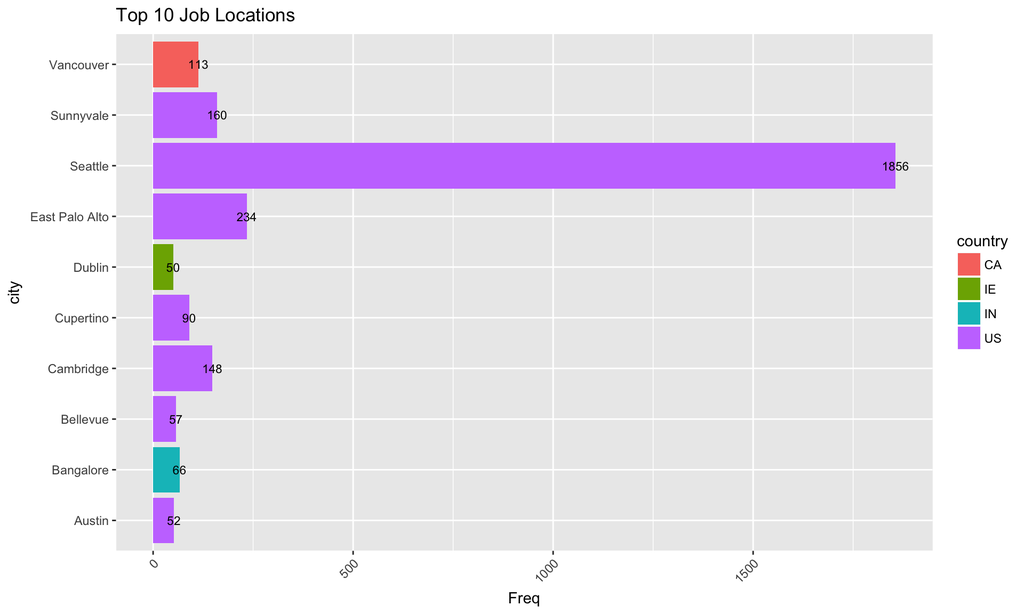

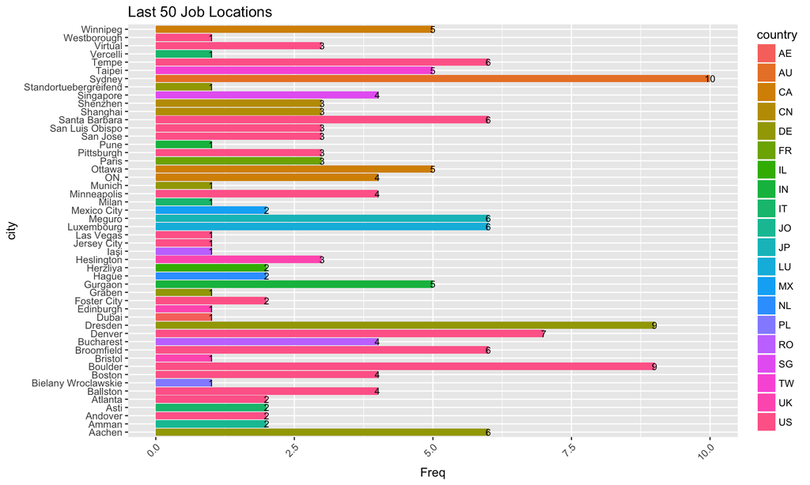

Distribution of Jobs in all countries except US

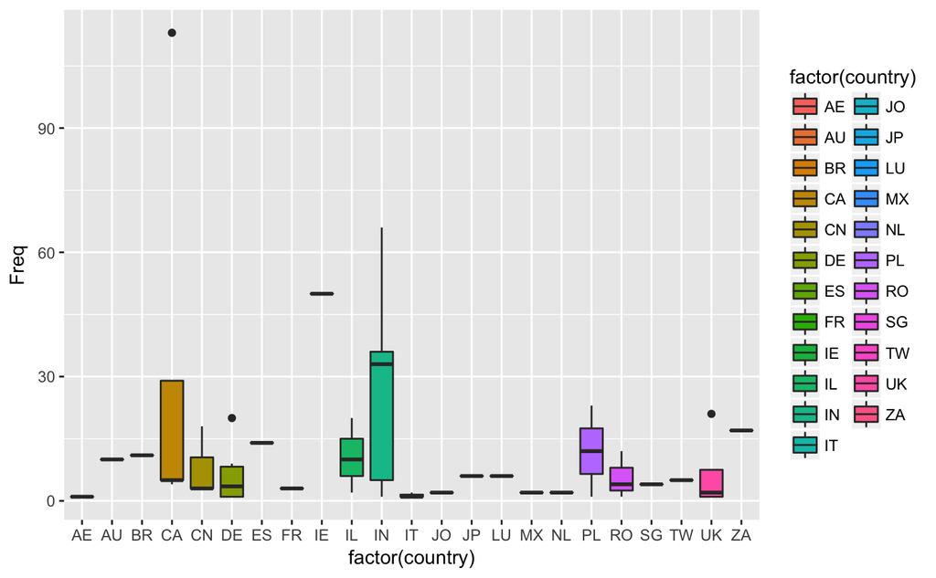

```r
p3 <- ggplot(filter(loc1,loc1$country!="US"), aes(x=factor(country), y=Freq, fill = factor(country))) +
  geom_boxplot()
p3
```

Distribution of jobs in US

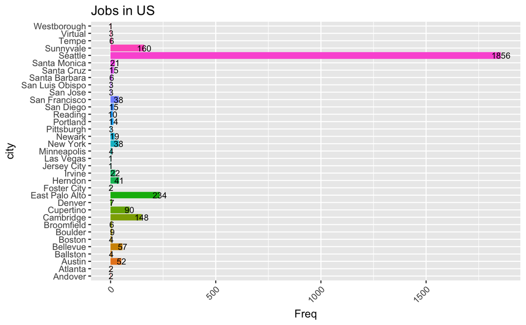

```r
p4 <- ggplot(data = filter(loc1, loc1$country == "US"), aes(city, Freq, fill = city)) +
      geom_bar(stat = "identity") +
      geom_text(aes(label=Freq), color="black", size=3) +
      ggtitle("Jobs in US") +
      coord_flip() +
      guides(fill=FALSE) +
      tilt_theme
p4
```

# Analysis of Job Posting Date

## How many jobs are posted every year and every month? Is there a certain period of year when jobs are posted more fequently?

```r
amazon$Posting_date <- paste(amazon$posting_year, amazon$posting_month, amazon$posting_day,sep="-")
amazon$Posting_date <- as.Date(strptime(amazon$Posting_date,format="%Y-%b-%d"))
#amazon$Posting_date$zone <- NULL
(amazon$Posting_date[1:10])
```

```
 [1] "2018-03-01" "2018-03-01" "2018-03-01" "2018-03-01" "2018-03-01" "2018-03-01" "2018-03-01" "2018-03-01"
 [9] "2018-03-01" "2018-03-01"
```

```r
#get day of the week based on date
dow <- function(x) format(as.Date(x), "%A")
amazon$weekday <- dow(amazon$Posting_date)
amazon$weekday[1:20]
```

```
 [1] "Thursday"  "Thursday"  "Thursday"  "Thursday"  "Thursday"  "Thursday"  "Thursday"  "Thursday"  "Thursday"
[10] "Thursday"  "Thursday"  "Thursday"  "Thursday"  "Wednesday" "Wednesday" "Wednesday" "Wednesday" "Wednesday"
[19] "Wednesday" "Wednesday"
```

```r
posting_date <- amazon[,c("posting_month", "posting_year", "weekday", "Posting_date")]
head(posting_date)
```

| posting_month | posting_year | weekday | Posting_date |
| --- | --- | --- | --- |
| March | 2018 | Thursday | 2018-03-01 |
| March | 2018 | Thursday | 2018-03-01 |
| March | 2018 | Thursday | 2018-03-01 |
| March | 2018 | Thursday | 2018-03-01 |
| March | 2018 | Thursday | 2018-03-01 |
| March | 2018 | Thursday | 2018-03-01 |

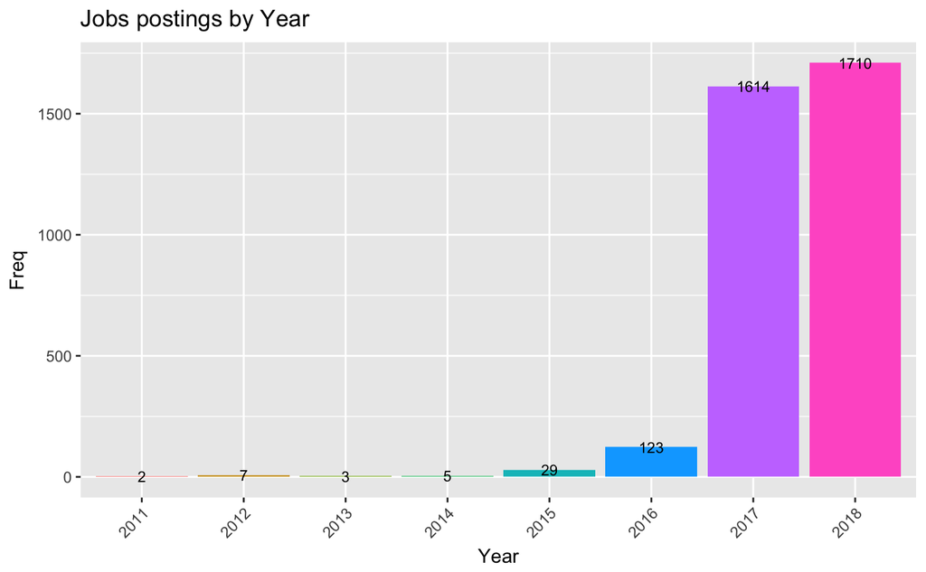

```r
year <- as.data.frame(table(posting_date$posting_year))
colnames(year) <- c("Year", "Freq")
p5 <- ggplot(data = year, aes(Year, Freq, fill = Year)) +
      geom_bar(stat = "identity") +
      geom_text(aes(label=Freq), color="black", size=3) +
      ggtitle("Jobs postings by Year") +
      guides(fill=FALSE) +
      tilt_theme
p5
```

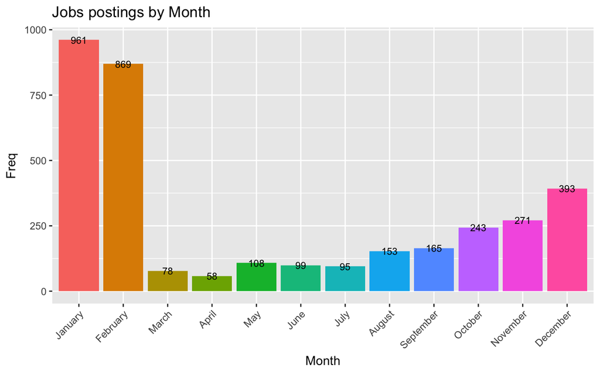

```r
mon <- as.data.frame(table(posting_date$posting_month))
colnames(mon) <- c("Mon", "Freq")
lev = c("January", "February", "March", "April", "May", "June", "July", "August", "September", "October", "November", "December")
mon$Month <- factor(mon$Mon, lev)

p6 <- ggplot(data = mon, aes(Month, Freq, fill = Month)) +
      geom_bar(stat = "identity") +
      geom_text(aes(label=Freq), color="black", size=3) +
      ggtitle("Jobs postings by Month") +
      guides(fill=FALSE) +
      tilt_theme
p6
```

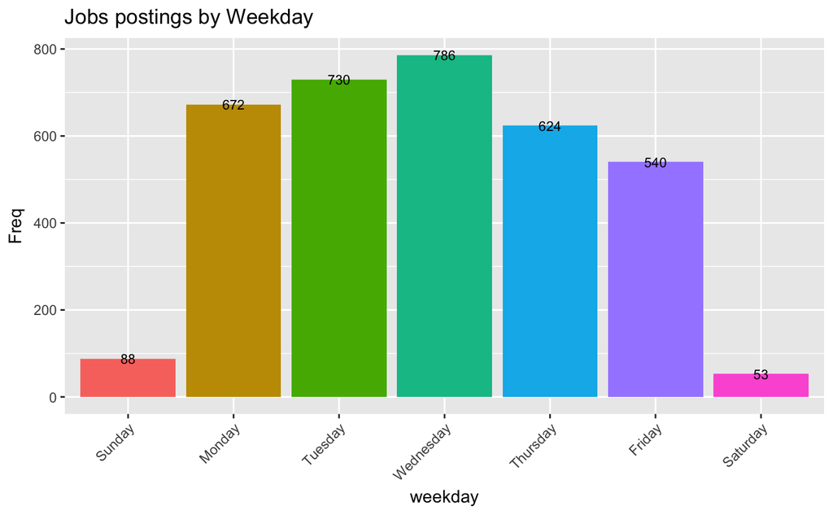

```r
jday <- as.data.frame(table(posting_date$weekday))
colnames(jday) <- c("wd", "Freq")
lev <- c("Sunday", "Monday", "Tuesday", "Wednesday", "Thursday", "Friday", "Saturday")
jday$weekday <- factor(jday$wd, lev)
p7 <- ggplot(data = jday, aes(weekday, Freq, fill = weekday)) +
      geom_bar(stat = "identity") +
      geom_text(aes(label=Freq), color="black", size=3) +
      ggtitle("Jobs postings by Weekday") +
      guides(fill=FALSE) +
      tilt_theme
p7
```

The above graphs show that most of the job postings are recent and there has been large increase in jobs in 2017 and 2018. January and february are hot months for jobs. Also, the jobs are posted generally on weekdays, mostly on tuesdays and wednesday. This is true as generally employees are completing more work in the first half of weekdays.

# Analysis of Job titles

## What are most popular job titles?

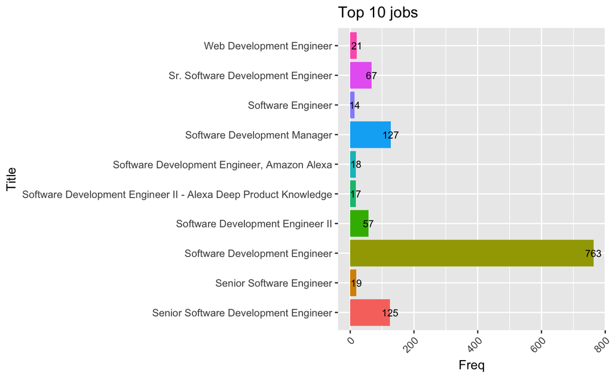

```r
title <- arrange(as.data.frame(table(amazon$Title)), desc(Freq))
colnames(title) <- c("Title", "Freq")
p8 <- ggplot(data = head(title, 10), aes(Title, Freq, fill = Title)) +
      geom_bar(stat = "identity") +
      geom_text(aes(label=Freq), color="black", size=3) +
      ggtitle("Top 10 jobs") +
      guides(fill=FALSE) +
      coord_flip() +
      tilt_theme
p8
```

There are various job postings. Top 10 are shown above. Let us now divide it in different domains and different positions.

```r
# software, game, quality, data, web, security, sale,iot, research
# lead, manager, developer, engineer, consultant, artist, analyst, scientist,
domain <- c("software", "game", "quality", "data", "web", "security", "sale", "research", "iot", "ui")
positions <- c("lead", "leader","manager", "developer", "engineer", "consultant", "artist", "analyst", "scientist")
amazon$Title <- tolower(amazon$Title)
#unique(amazon$Title)
amazon$domain <- NA
amazon$positions <- NA
```

```r
for(i in domain){
amazon$domain1 <- grepl(i, amazon$Title)
amazon$domain <- ifelse(amazon$domain1 == "TRUE", i, amazon$domain)
}
amazon$domain <- ifelse(amazon$domain == FALSE, "other", amazon$domain)
for(i in positions){
  amazon$pos1 <- grepl(i, amazon$Title)
  amazon$positions <- ifelse(amazon$pos1 == "TRUE", i, amazon$positions)
}
amazon$positions <- ifelse(is.na(amazon$positions), "other", amazon$positions)
amazon <- subset(amazon, select = -c(domain1, pos1))
```

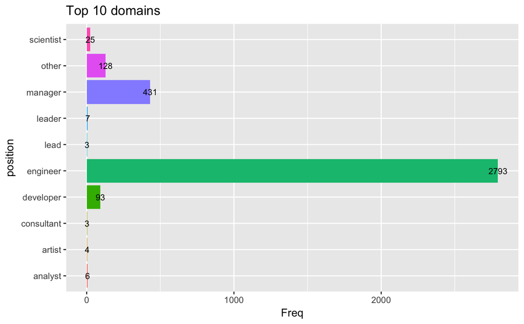

```r
pos <- as.data.frame(table(amazon$positions))
colnames(pos) <- c("position", "Freq")
p9 <- ggplot(data = pos, aes(position, Freq, fill = position)) +
      geom_bar(stat = "identity") +
      geom_text(aes(label=Freq), color="black", size=3) +
      ggtitle("Top 10 domains") +
      guides(fill=FALSE) +
      coord_flip()
p9
```

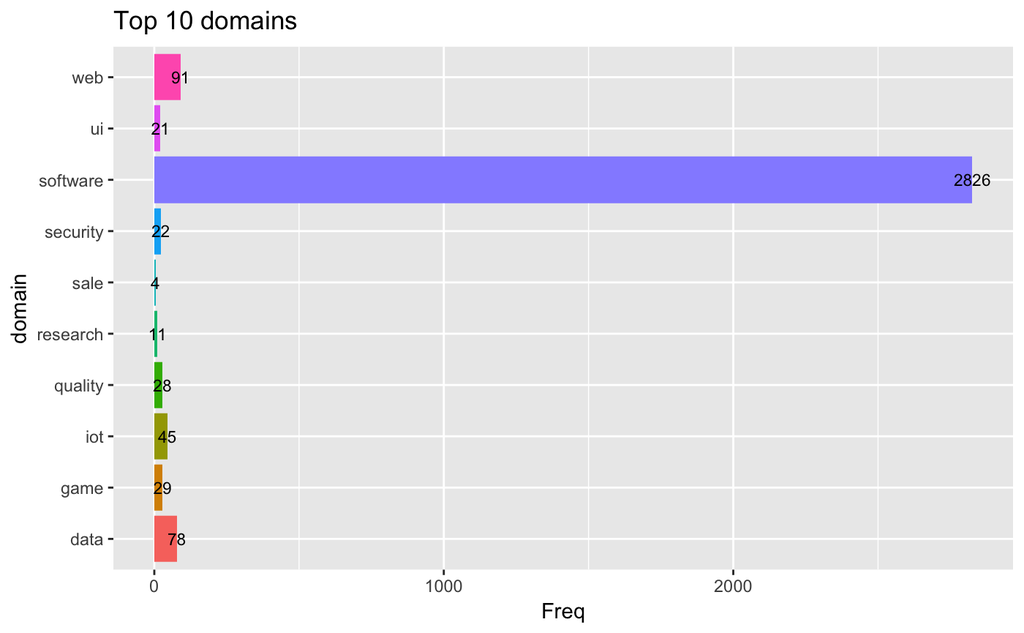

```r
dom <- as.data.frame(table(amazon$domain))
colnames(dom) <- c("domain", "Freq")
p9 <- ggplot(data = dom, aes(domain, Freq, fill = domain)) +
      geom_bar(stat = "identity") +
      geom_text(aes(label=Freq), color="black", size=3) +
      ggtitle("Top 10 domains") +
      guides(fill=FALSE) +
      coord_flip()
p9
```

# What are minimum educational qualifications?

```r
amazon$education <- NA
degree_list = c("ba", "bs", "b.tech","bachelor", "phd","ms","master", "mba","m.tech")
amazon$`BASIC QUALIFICATIONS` <- tolower(amazon$`BASIC QUALIFICATIONS`)
for(i in degree_list){
  amazon$deg1 <- grepl(i, amazon$`BASIC QUALIFICATIONS`)
  amazon$education <- ifelse(amazon$deg1 == "TRUE", i, amazon$education)
}
amazon$education <- ifelse(is.na(amazon$education), "other", amazon$education)
amazon <- subset(amazon, select = -c(deg1))
```

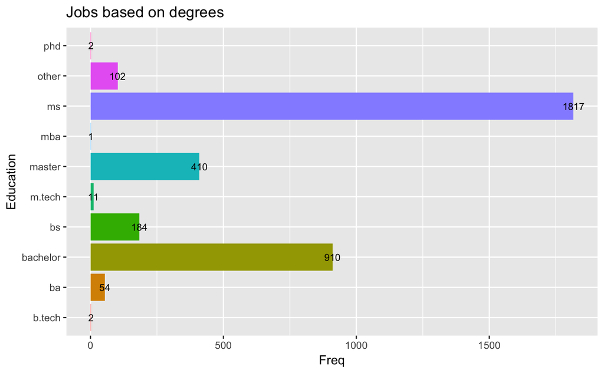

```r
edu <- as.data.frame(table(amazon$education))
colnames(edu) <- c("Education", "Freq")
p10 <- ggplot(data = edu, aes(Education, Freq, fill = Education)) +
      geom_bar(stat = "identity") +
      geom_text(aes(label=Freq), color="black", size=3) +
      ggtitle("Jobs based on degrees") +
      guides(fill=FALSE) +
      coord_flip()
p10
```

Basic Qualifications generally requires Masters degree.

## Which jobs require which type of degrees?

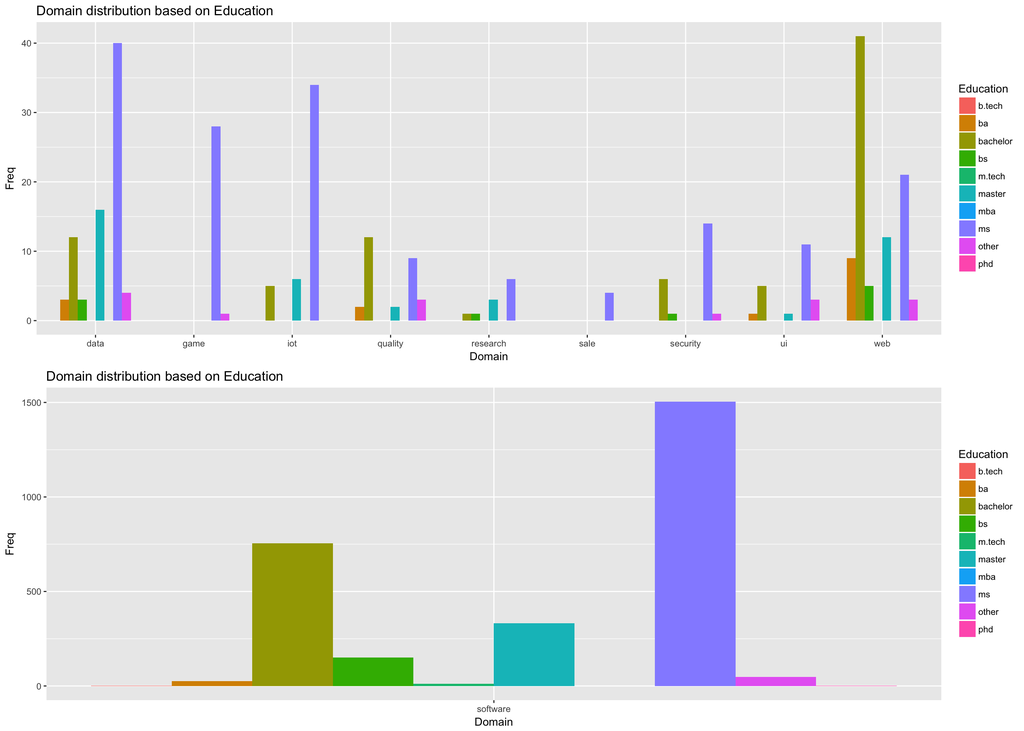

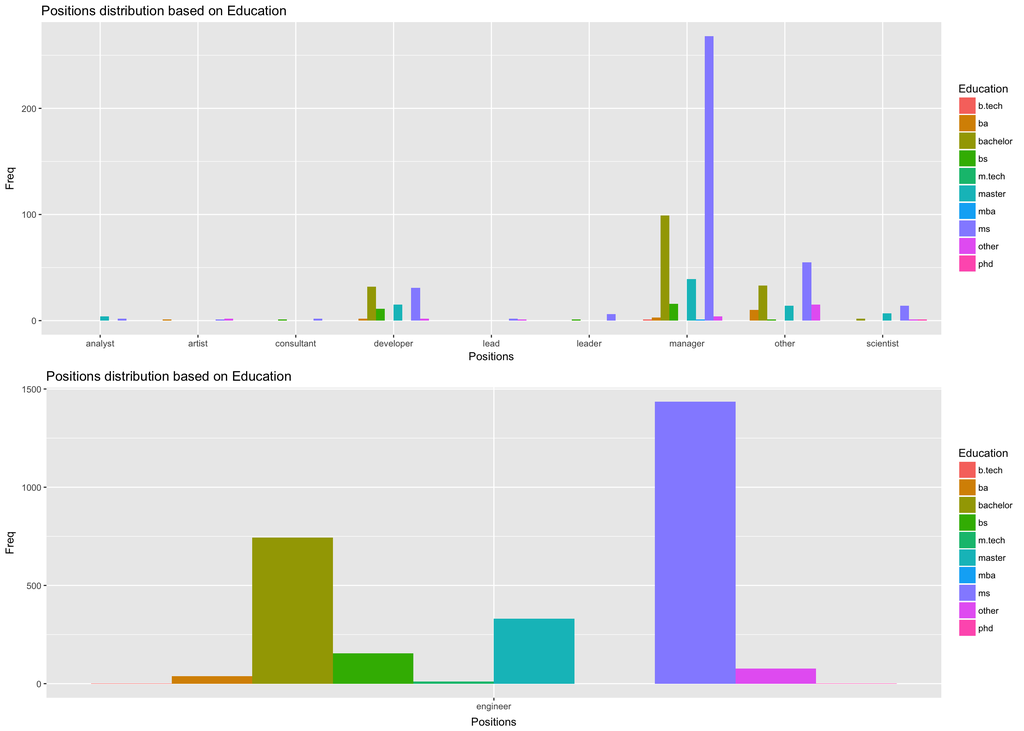

# What languages are in demand?

```r
list_of_occurence <- c()
languages <- c('swift','matlab','mongodb','hadoop','cosmos', 'mysql','spark', 'pig', 'python', 'java.', 'java,','c[++]', 'php', 'javascript', 'objective c', 'ruby', 'perl','c ','c#', ' r,')
amazon$`PREFERRED QUALIFICATIONS` <- tolower(amazon$`PREFERRED QUALIFICATIONS`)
for(i in languages){
  amazon$dummy <- str_count(amazon$`PREFERRED QUALIFICATIONS`, i)
  list_of_occurence <- c(list_of_occurence, sum(amazon$dummy, na.rm = TRUE))
}
list_of_occurence
```

```
 [1]   26    9   16  164    1   50  128   20  378 1080  392  504   34  348   79  237  188  630  139    7
```

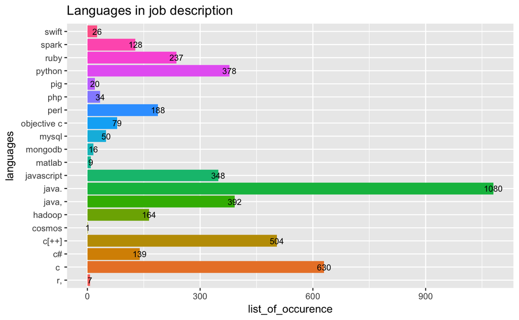

```r
lan <- data.frame(cbind(languages, as.numeric(list_of_occurence)))
p15 <- ggplot(data = lan, aes(languages, list_of_occurence, fill = languages)) +
      geom_bar(stat = "identity") +
      geom_text(aes(label=list_of_occurence), color="black", size=3) +
      ggtitle("Languages in job description") +
      guides(fill=FALSE) +
      coord_flip()
p15
```

Java, C, C++ and python are popular on-demand languages in jobs.

# How many years of experience is required?

```r
amazon$dummy <- str_extract(amazon$`BASIC QUALIFICATIONS`, '([0-9]+) year')
amazon$dummy <- ifelse(is.na(amazon$dummy), "0 year", amazon$dummy)
split_year <- function(var){
 return(as.numeric(unlist(str_split(var, " "))[1]))
}
amazon$experience <- sapply(amazon$dummy, split_year)
```

Let’s see the experience, excluding 0 year experience.

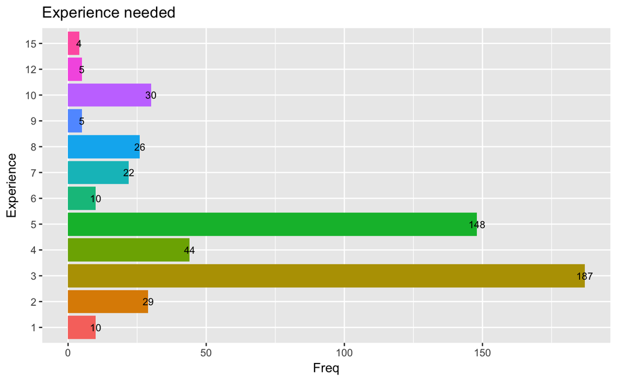

```r
exp <- as.data.frame(table(amazon$experience))
colnames(exp) <- c("Experience", "Freq")
p16 <- ggplot(data = filter(exp, exp$Experience != 0), aes(Experience, Freq, fill = Experience)) +
      geom_bar(stat = "identity") +
      geom_text(aes(label=Freq), color="black", size=3) +
      ggtitle("Experience needed") +
      guides(fill=FALSE) +
      coord_flip()
p16
```

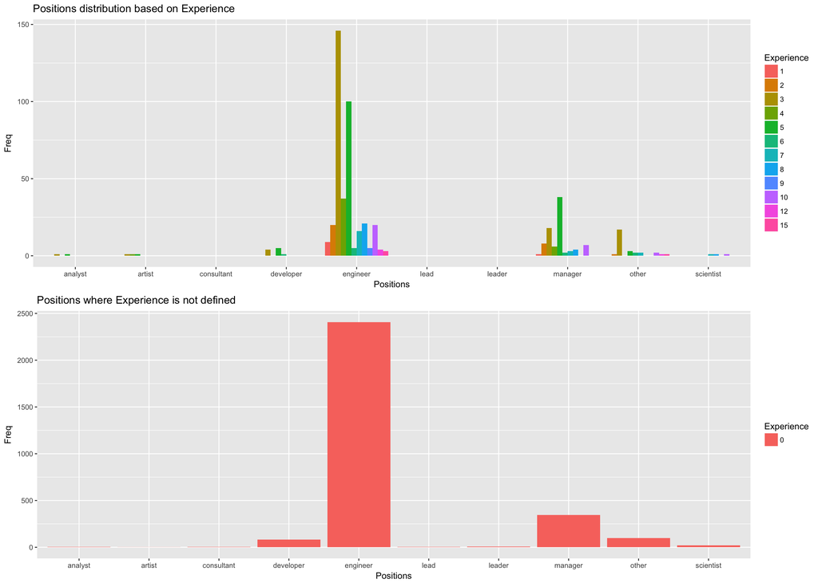

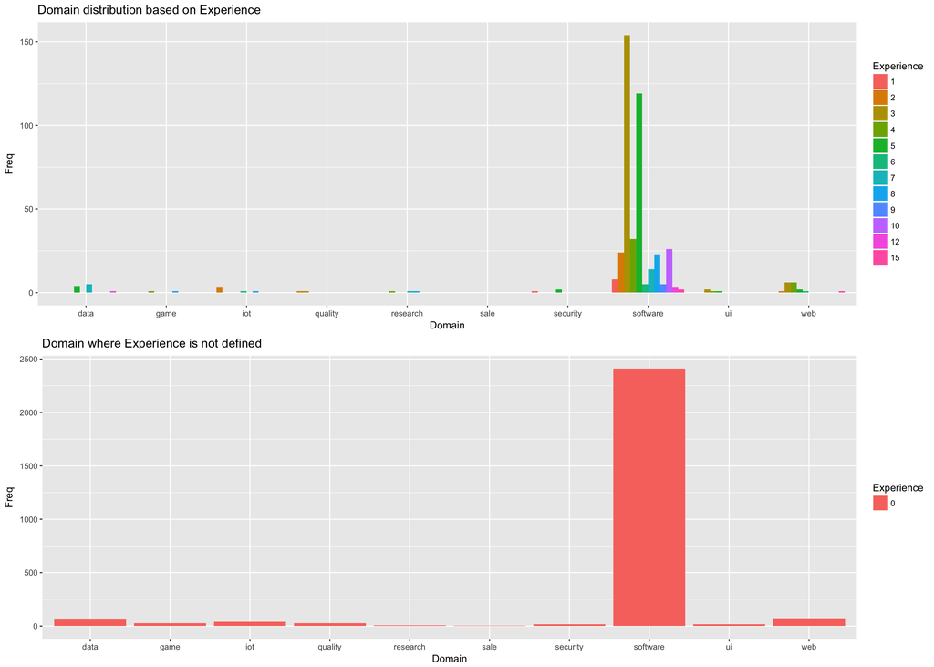